# Sample Project

## Indicadores de salud del suelo

La siguiente tabla describe: 1. Lo que cada indicador ayuda a medir en su suelo; 2. Si desea que el valor medido sea más alto (más es mejor), más bajo (menos es mejor), o en el medio (rango óptimo); y 3. Con qué frecuencia medir cada indicador. Esta tabla refleja nuestro conocimiento actual, aunque la ciencia evoluciona rápidamente a medida que los investigadores miden estos indicadores en diversos suelos, sistemas de cultivo y climas.

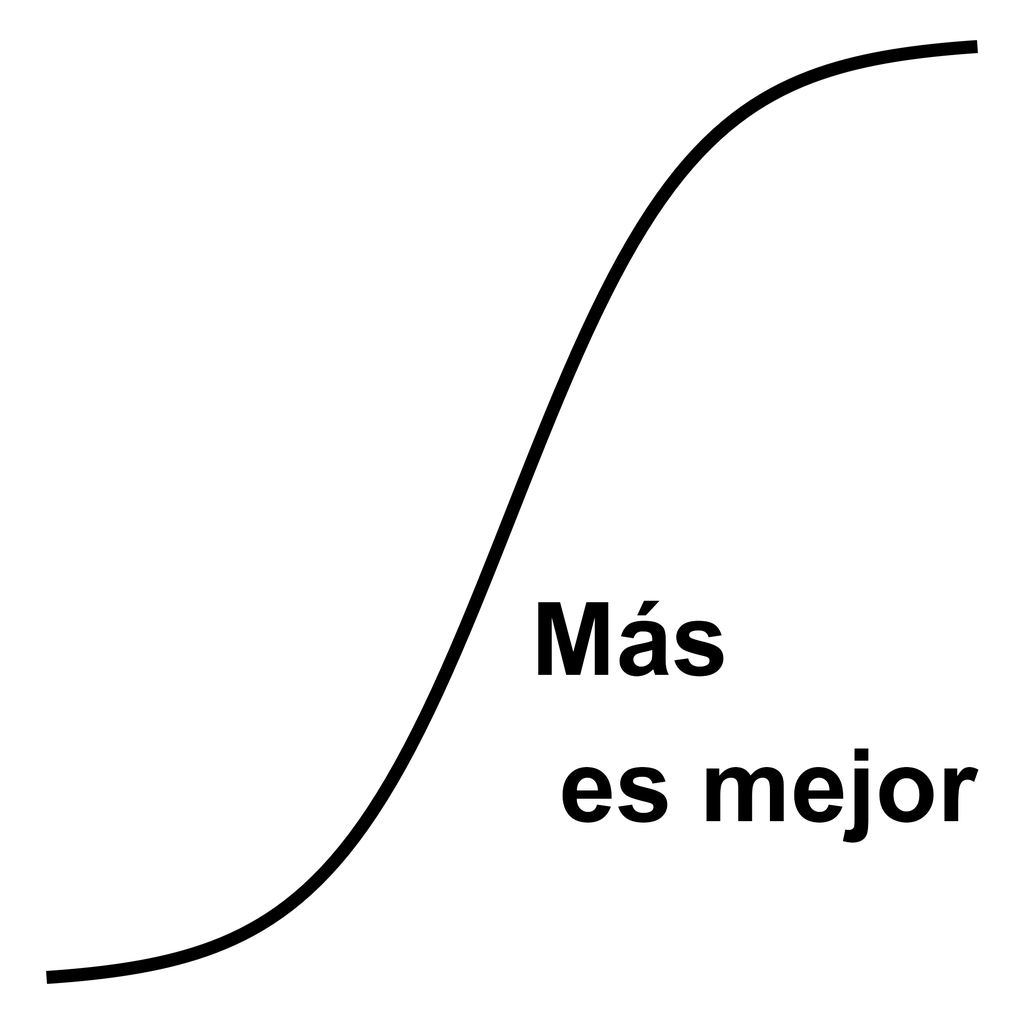

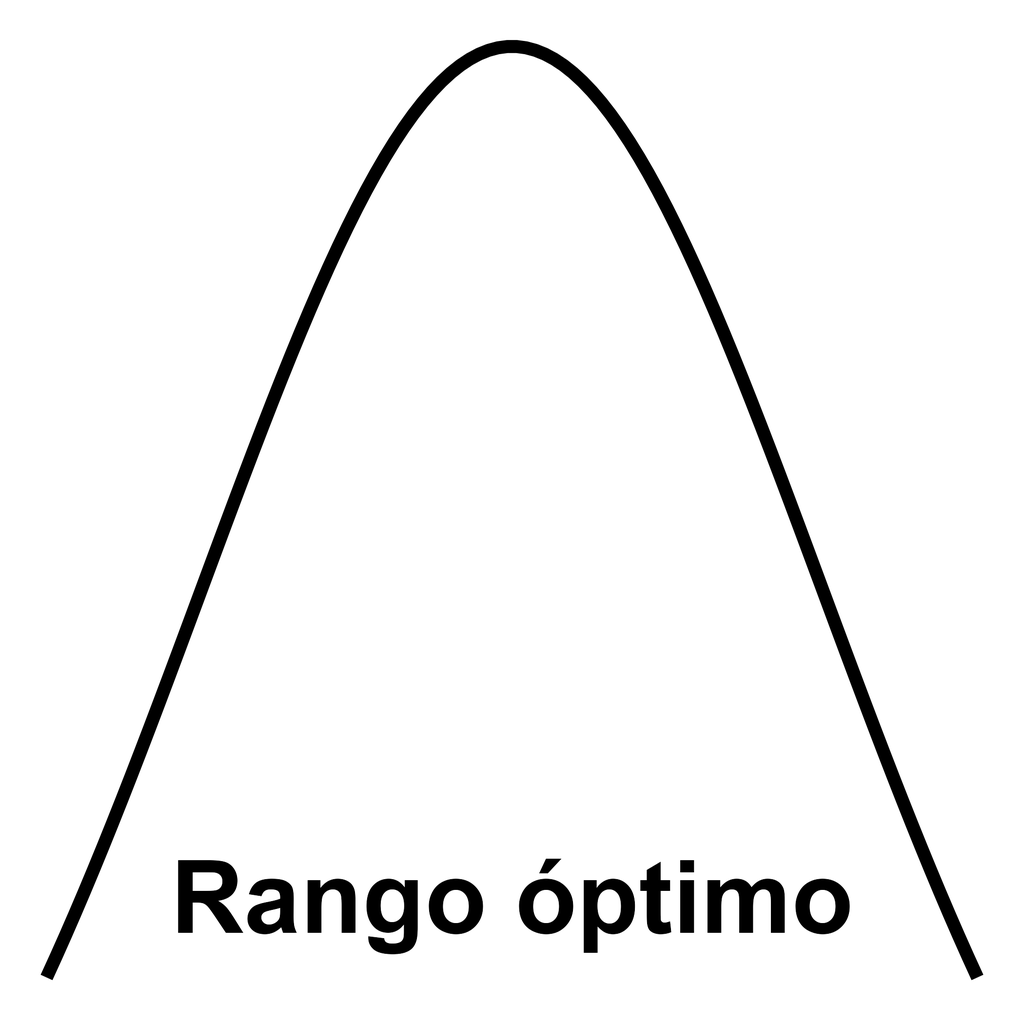

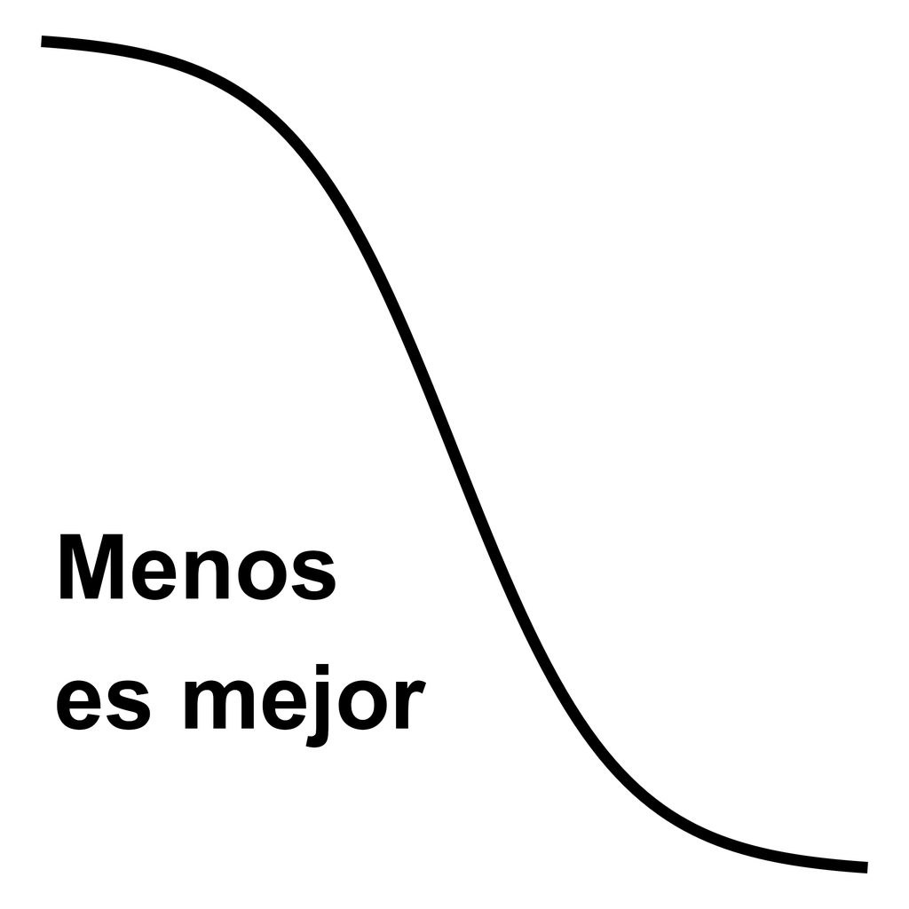

| Indicadores de salud del suelo | Función del suelo | Tipo de curva y mejoría |
| --- | --- | --- |
| Medir cada: 1-3 años |  |  |
| El carbono potencialmente mineralizable (MinC) | Ciclo de nutrientes, biodiversidad y hábitat, filtración y resiliencia | Más es mejor |
| El pH del suelo | Nutrient cycling, filtración y resiliencia | Rango óptimo |
| Nitrógeno total | Ciclo de nutrientes, biodiversidad y hábitat, filtración y resiliencia | Rango óptimo |
| Medir cada: 3-5 años |  |  |
| Densidad aparente | Soporte físico, relaciones hídricas, biodiversidad y hábitat, filtración y resiliencia | Rango óptimo |

## Pruebas de salud del suelo

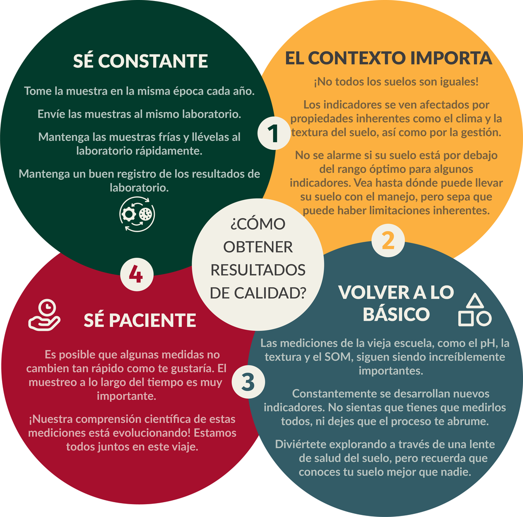

## Comprender los resultados de la salud del suelo

Para obtener más información sobre cómo interpretar los resultados de la salud del suelo, vea [“Comprender las pruebas de suelo”](https://youtu.be/-ED-gGk4yb8?si=fxfnxqrRqhkGDaiu) el seminario web de la Iniciativa sobre la Salud del Suelo de Washington.

## Su campos

| ID de muestra | Campo | Cultivo | Longitud | Latitud |
| --- | --- | --- | --- | --- |
| 24-GEH01-01 | Campo 01 | Pasture, Seeded | -122 | 49 |
| 24-GEH01-04 | Campo 04 | Pasture, Seeded | -122 | 49 |

[interactive chart not shown]

## Resultados del proyecto

### Mediciones físicas

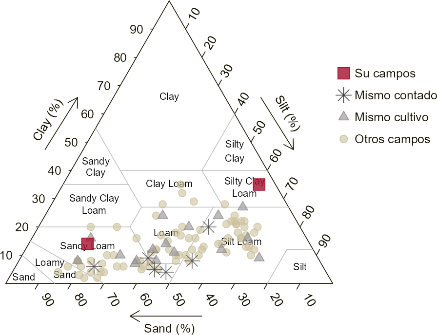

[output not shown]

Valores ≥ promedio de proyectos tienen fondos más oscuros. Valores < promedio de proyectos tienen fondos más claros

[interactive chart not shown]

### Mediciones biológicas

| Campo o Promedio | Materia organica % | Min C mg/kg/day |
| --- | --- | --- |
| Campo 01 | 7.1 | 60 |
| Campo 04 | 6.2 | 71 |
| Pasture, Seeded Promedio (18 Campos) | 5.7 | 68 |
| Condado 20 Promedio (8 Campos) | 12.0 | 60 |
| Promedio del proyecto (100 Campos) | 5.5 | 48 |

Valores ≥ promedio de proyectos tienen fondos más oscuros. Valores < promedio de proyectos tienen fondos más claros

[interactive chart not shown]

### Mediciones químicas

| Campo o Promedio | pH | EC dS/cm | CEC cmolc/kg | Total C % | TOC % | Total N % | NO₃-N ppm | NH₄-N ppm |
| --- | --- | --- | --- | --- | --- | --- | --- | --- |
| Campo 01 | 5.4 | 0.26 | 45 | 3.1 | 3.1 | 0.26 | 2.5 | 6.3 |
| Campo 04 | 5.7 | 0.31 | 48 | 2.8 | 2.8 | 0.23 | 1.6 | 5.8 |
| Pasture, Seeded Promedio (18 Campos) | 6.0 | 0.35 | 19 | 2.8 | 2.8 | 0.22 | 6.4 | 11.0 |
| Condado 20 Promedio (8 Campos) | 5.6 | 0.63 | 26 | 5.9 | 5.9 | 0.35 | 11.0 | 10.0 |
| Promedio del proyecto (100 Campos) | 6.0 | 0.62 | 15 | 2.7 | 2.7 | 0.20 | 15.0 | 9.2 |

Valores ≥ promedio de proyectos tienen fondos más oscuros. Valores < promedio de proyectos tienen fondos más claros

[interactive chart not shown]

## Reconocimiento

Este informe se generó con la herramienta [Dirt Data Reports tool](https://wsda.shinyapps.io/dirt-data-reports/). El Departamento de Agricultura del Estado de Washington (WSDA) desarrolló con base en [el paquete R {soils}](https://wa-department-of-agriculture.github.io/soils/), creado por el WSDA y la Universidad Estatal de Washington como parte de la [Iniciativa sobre la Salud del Suelo de Washington](https://washingtonsoilhealthinitiative.com/). El contenido y las figuras fueron adaptadas de la publicación de estension universitaria de el estado de Washington [#FS378E Soil Health in Washington Vineyards](https://pubs.extension.wsu.edu/soil-health-in-washington-vineyards).

El texto del reporte y las imágenes fueron traducidas por Erica Tello, Eber Rivera, y Kate Smith con WSU Food Systems y Skagit County Extension como parte del programa de USDA NRCS Innovación en la conservación, dirigido por Viva Farms (grant number NR22-13G004).